# DATA 624: PREDICTIVE ANALYTICS HW 8

Gabriel Campos

Last edited April 07, 2024

# Library

```r
library(AppliedPredictiveModeling)
library(caret)
library(corrplot)
library(earth)
library(fpp3)
library(dplyr)
library(ggplot2)
library(mlbench)
library(RANN)
library(tidyr)
```

# Description

Do problems 7.2 and 7.5 in Kuhn and Johnson. There are only two but they have many parts. Please submit both a link to your Rpubs and the .rmd file.

# 7.2

Friedman (1991) introduced several benchmark data sets create by simulation One of these simulations used the following nonlinear equation to create data:

$y=10sin(\pi1x_1x_2)+20(x_3-0.5)^2+10x_4+5x_5+N(0,\sigma^2)$

where the *x* values are random variables uniformly distributed between [0, 1] (there are also 5 other non-informative variables also created in the simulation). The package `mlbench` contains a function called **mlbench.friedman1** that simulates these data:

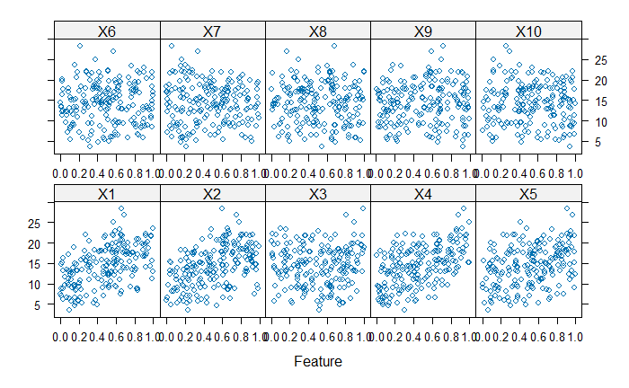

```r
set.seed(200)
trainingData <- mlbench.friedman1(200, sd = 1)
## We convert the 'x' data from a matrix to a data frame
## One reason is that this will give the columns names.
trainingData$x <- data.frame(trainingData$x)
## Look at the data using
featurePlot(trainingData$x, trainingData$y)
```

```r
## or other methods.

## This creates a list with a vector 'y' and a matrix
## of predictors 'x'. Also simulate a large test set to
## estimate the true error rate with good precision:
testData <- mlbench.friedman1(5000, sd = 1)
testData$x <- data.frame(testData$x)
```

## i

### Example

Tune several models on these data. For example:

```r
knnModel <- train(x = trainingData$x,
y = trainingData$y,
method = "knn",
preProc = c("center", "scale"),
tuneLength = 10)
knnModel
```

```
k-Nearest Neighbors

200 samples
 10 predictor

Pre-processing: centered (10), scaled (10)
Resampling: Bootstrapped (25 reps)
Summary of sample sizes: 200, 200, 200, 200, 200, 200, ...
Resampling results across tuning parameters:

  k   RMSE      Rsquared   MAE
   5  3.466085  0.5121775  2.816838
   7  3.349428  0.5452823  2.727410
   9  3.264276  0.5785990  2.660026
  11  3.214216  0.6024244  2.603767
  13  3.196510  0.6176570  2.591935
  15  3.184173  0.6305506  2.577482
  17  3.183130  0.6425367  2.567787
  19  3.198752  0.6483184  2.592683
  21  3.188993  0.6611428  2.588787
  23  3.200458  0.6638353  2.604529

RMSE was used to select the optimal model using the smallest value.
The final value used for the model was k = 17.
```

```r
knnPred <- predict(knnModel, newdata = testData$x)
## The function 'postResample' can be used to get the test set
## perforamnce values
postResample(pred = knnPred, obs = testData$y)
```

```
     RMSE  Rsquared       MAE
3.2040595 0.6819919 2.5683461
```

### MARS & MARS TUNED

#### MARS

```r
mars_Grid <- expand.grid(.degree = 1:2, .nprune = 2:38)
set.seed(100)

mars_Fit <- earth(trainingData$x, trainingData$y)

mars_Pred <- predict(mars_Fit, newdata = testData$x)
postResample(pred = mars_Pred, obs = testData$y)
```

```
     RMSE  Rsquared       MAE
1.8136467 0.8677298 1.3911836
```

#### MARS Tuned

```r
marsTuned_Grid <- expand.grid(.degree = 1:2, .nprune = 2:38)
set.seed(100)

marsTuned <- train(trainingData$x, trainingData$y, method = "earth",
                   tuneGrid = marsTuned_Grid,
                   trControl = trainControl(method = "cv"))

marsTune_Pred <- predict(marsTuned, newdata = testData$x)
postResample(pred = marsTune_Pred, obs = testData$y)
```

```
     RMSE  Rsquared       MAE
1.1589948 0.9460418 0.9250230
```

### SVM Tuned

```r
svmRTuned <- train(trainingData$x, trainingData$y,
                   method = "svmRadial",
                   preProcess = c("center", "scale"),
                   tuneLength = 15,
                   trControl = trainControl(method = "cv"))

svmPred <- predict(svmRTuned, newdata = testData$x)
postResample(svmPred, testData$y)
```

```
     RMSE  Rsquared       MAE
2.0741473 0.8255848 1.5755185
```

## ii

Which models appear to give the best performance?

MAR tuned model with an R-squared value of 0.9460 looks like its the best performing.

## iii

Does MARS select the informative predictors (those named X1–X5)?

Yes it selects for informative predictors

# 7.5

Exercise 6.3 describes data for a chemical manufacturing process. Use the same data imputation, data splitting, and pre-processing steps as before and train several nonlinear regression models.

## Load Data

```r
data(ChemicalManufacturingProcess)
```

## data imputation, data splitting & pre-processing

**impute**

```r
imputed_df <- preProcess(ChemicalManufacturingProcess, "knnImpute")
imputed_full_df <- predict(imputed_df, ChemicalManufacturingProcess)
```

```r
val_low <- nearZeroVar(imputed_full_df)
#remove low frequency columns using baser df[row,columns]
chem_df <- imputed_full_df[,-val_low]
```

**split**

```r
chem_index <- createDataPartition(chem_df$Yield , p=.8, list=F)
```

```r
chem_train <-  chem_df[chem_index,]
chem_test <- chem_df[-chem_index,]
```

```r
chem_marsGrid <- expand.grid(.degree = 1:2, .nprune = 2:38)
```

## (a)

Which nonlinear regression model gives the optimal resampling and test set performance?

### MARS Tuned

```r
chem_MarsTuned <- train(Yield~. ,
                  data = chem_train,
                   method = "earth",
                   tuneGrid = chem_marsGrid,
                   trControl = trainControl(method = "cv"))

chem_MarsTunePred <- predict(chem_MarsTuned,  chem_test)
postResample(chem_MarsTunePred, chem_test$Yield)
```

```
     RMSE  Rsquared       MAE
0.6437705 0.5394597 0.4739508
```

### SVM Tuned

```r
chem_SVMTuned <- train(Yield~. ,
                  data = chem_test,
                   method = "svmRadial",
                   tuneLength = 15,
                   trControl = trainControl(method = "cv"))

chem_SVMTunePred <- predict(chem_SVMTuned,  chem_test)
postResample(chem_SVMTunePred, chem_test$Yield)
```

```
      RMSE   Rsquared        MAE
0.09178983 0.99520810 0.09087154
```

### KNN

```r
knnModel <- train(Yield~.,
                    data = chem_test,
                    method = "knn",
                    preProc = c("center", "scale"),
                    tuneLength = 10)

knnPred <- predict(knnModel,  chem_test)
postResample(pred = knnPred, obs = chem_test$Yield)
```

```
     RMSE  Rsquared       MAE
0.7631649 0.4717384 0.6279725
```

### Neural Network

```r
nnetGrid <- expand.grid(.decay = c(0, 0.01, .1),
                        .size = c(1:10), .bag = FALSE)

nnetTune <- train(Yield~.,
                  data = chem_train,
                  method = "avNNet",
                  tuneGrid = nnetGrid,
                  trControl = trainControl(method = "cv"),
                  linout = TRUE,trace = FALSE,
                  MaxNWts = 10 * (ncol(chem_train) + 1) + 10 + 1,
                  maxit = 500)
```

```r
nnetPred <- predict(nnetTune,  chem_test)
postResample(predict(nnetTune,  chem_test), chem_test$Yield)
```

```
     RMSE  Rsquared       MAE
0.6145770 0.6353956 0.4907860
```

The SVM tuned is the best performing RMSE and R squared with values of RMSE=0.09178983 , and R squared=0.99520810

## (b)

Which predictors are most important in the optimal nonlinear regression model? Do either the biological or process variables dominate the list?How do the top ten important predictors compare to the top ten predictors from the optimal linear model?

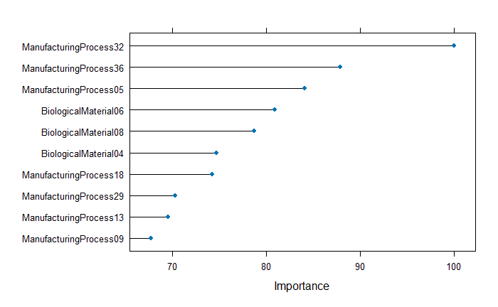

```r
plot(varImp(chem_SVMTuned), top=10)
```

## (c)

Explore the relationships between the top predictors and the response for the predictors that are unique to the optimal nonlinear regression model. Do these plots reveal intuition about the biological or process predictors and their relationship with yield?

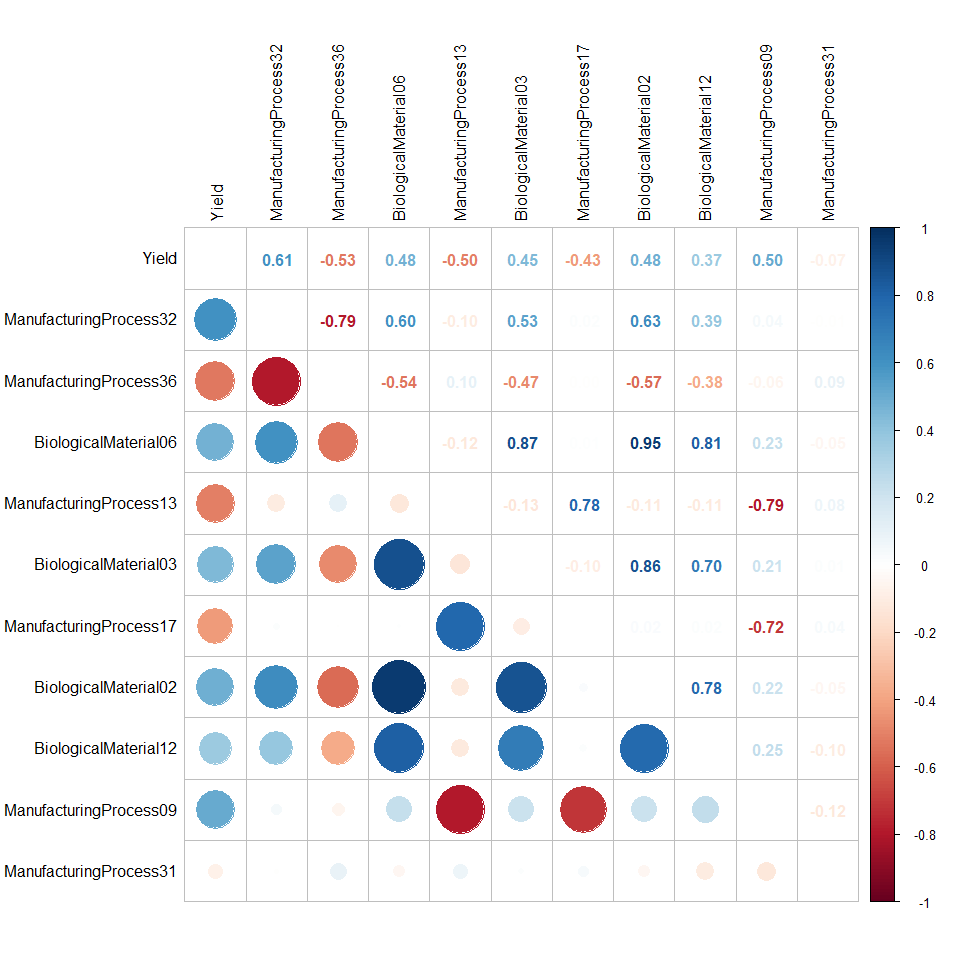

```r
corr_vals <- chem_df %>%
  dplyr::select('Yield', 'ManufacturingProcess32','ManufacturingProcess36',
         'BiologicalMaterial06','ManufacturingProcess13',
         'BiologicalMaterial03','ManufacturingProcess17',
         'BiologicalMaterial02','BiologicalMaterial12',
         'ManufacturingProcess09','ManufacturingProcess31')

corr_plot_vals <- cor(corr_vals)

corrplot.mixed(corr_plot_vals, tl.col = 'black', tl.pos = 'lt',
         upper = "number", lower="circle")
```